# Credit_Card_Fraud_Analysis_DAE_EXACT_REFERENCE_STYLE

**Step-1: Data Collection**  
The dataset used for this project was collected for Credit Card Fraud Analysis. It contains transaction, customer, card, merchant, device, authentication, risk and fraud-related information.

**Step-2: Data Loading**

```python
import pandas as pd
import numpy as np

df=pd.read_csv("credit_card_fraud_analysis_6plus_years.csv")
print(df)
```

```
       transaction_id  amount  transaction_hour merchant_category  \
0                 NaN     NaN               NaN               NaN
1                 NaN     NaN               NaN               NaN
2                 NaN     NaN               NaN               NaN
3                 NaN     NaN               NaN               NaN
4                 NaN     NaN               NaN               NaN
...               ...     ...               ...               ...
59995          9996.0  350.91              22.0              Food
59996          9997.0  410.04               5.0          Clothing
59997          9998.0  527.75              21.0       Electronics
59998          9999.0   91.20               2.0       Electronics
59999         10000.0   44.06               2.0          Clothing

       foreign_transaction  location_mismatch  device_trust_score  \
0                      NaN                NaN                 NaN
```

[output cut: 51 more lines]

[output not shown]

**Step-3: Data Exploration**

```python
df.head()
```

|  | transaction_id | amount | transaction_hour | merchant_category | foreign_transaction | location_mismatch | device_trust_score | velocity_last_24h | cardholder_age | is_fraud | ... | Chargeback | Alert_Generated | Risk_Score | Customer_Country | Customer_State | Customer_City | Year | Month | Quarter | Month_Name |
| --- | --- | --- | --- | --- | --- | --- | --- | --- | --- | --- | --- | --- | --- | --- | --- | --- | --- | --- | --- | --- | --- |
| 0 | NaN | NaN | NaN | NaN | NaN | NaN | NaN | NaN | NaN | NaN | ... | No | No | 34.61 | India | Telangana | Guntur | 2020.0 | 1.0 | 1.0 | January |
| 1 | NaN | NaN | NaN | NaN | NaN | NaN | NaN | NaN | NaN | NaN | ... | No | No | 67.67 | India | West Bengal | Bengaluru | 2020.0 | 1.0 | 1.0 | January |
| 2 | NaN | NaN | NaN | NaN | NaN | NaN | NaN | NaN | NaN | NaN | ... | No | No | 43.63 | India | Telangana | Warangal | 2020.0 | 1.0 | 1.0 | January |
| 3 | NaN | NaN | NaN | NaN | NaN | NaN | NaN | NaN | NaN | NaN | ... | No | No | 40.80 | India | Delhi | Vijayawada | 2020.0 | 1.0 | 1.0 | January |
| 4 | NaN | NaN | NaN | NaN | NaN | NaN | NaN | NaN | NaN | NaN | ... | No | No | 28.83 | India | Andhra Pradesh | Vijayawada | 2020.0 | 1.0 | 1.0 | January |

5 rows × 69 columns

```python
df.tail()
```

|  | transaction_id | amount | transaction_hour | merchant_category | foreign_transaction | location_mismatch | device_trust_score | velocity_last_24h | cardholder_age | is_fraud | ... | Chargeback | Alert_Generated | Risk_Score | Customer_Country | Customer_State | Customer_City | Year | Month | Quarter | Month_Name |
| --- | --- | --- | --- | --- | --- | --- | --- | --- | --- | --- | --- | --- | --- | --- | --- | --- | --- | --- | --- | --- | --- |
| 59995 | 9996.0 | 350.91 | 22.0 | Food | 0.0 | 0.0 | 99.0 | 4.0 | 37.0 | 0.0 | ... | NaN | NaN | NaN | NaN | NaN | NaN | NaN | NaN | NaN | NaN |
| 59996 | 9997.0 | 410.04 | 5.0 | Clothing | 0.0 | 0.0 | 70.0 | 3.0 | 25.0 | 0.0 | ... | NaN | NaN | NaN | NaN | NaN | NaN | NaN | NaN | NaN | NaN |
| 59997 | 9998.0 | 527.75 | 21.0 | Electronics | 0.0 | 0.0 | 44.0 | 2.0 | 45.0 | 0.0 | ... | NaN | NaN | NaN | NaN | NaN | NaN | NaN | NaN | NaN | NaN |
| 59998 | 9999.0 | 91.20 | 2.0 | Electronics | 0.0 | 0.0 | 38.0 | 0.0 | 37.0 | 0.0 | ... | NaN | NaN | NaN | NaN | NaN | NaN | NaN | NaN | NaN | NaN |
| 59999 | 10000.0 | 44.06 | 2.0 | Clothing | 0.0 | 0.0 | 38.0 | 0.0 | 66.0 | 0.0 | ... | NaN | NaN | NaN | NaN | NaN | NaN | NaN | NaN | NaN | NaN |

5 rows × 69 columns

```python
df.shape
```

```
(60000, 69)
```

```python
df.columns
```

```
Index(['transaction_id', 'amount', 'transaction_hour', 'merchant_category',
       'foreign_transaction', 'location_mismatch', 'device_trust_score',
       'velocity_last_24h', 'cardholder_age', 'is_fraud', 'Transaction_ID',
       'Customer_ID', 'Card_ID', 'Transaction_DateTime', 'Card_Type',
       'Card_Category', 'Customer_Age', 'Customer_Gender', 'Customer_Income',
       'Credit_Limit', 'Credit_Score', 'Account_Age_Months',
       'Card_Tenure_Months', 'Transaction_Amount', 'Currency',
       'Merchant_Category', 'Merchant_ID', 'Merchant_Country', 'Merchant_City',
       'Transaction_Channel', 'Payment_Method', 'Device_ID', 'Device_Type',
       'Operating_System', 'Browser', 'IP_Address', 'IP_Risk_Score',
       'VPN_Used', 'Proxy_Used', 'Transaction_Hour', 'Day_of_Week',
       'Is_Weekend', 'Previous_Transaction_Gap_Minutes',
       'Transactions_Last_24H', 'Transactions_Last_7D',
       'Avg_Transaction_Amount_30D', 'Amount_Deviation_Pct',
       'Distance_From_Last_Transaction_KM', 'CVV_Provided', 'PIN_Used',
       'OTP_Used', 'Authentication_Method', 'Failed_Authentication_Count',
       'Card_Present', 'Fraud_Probability', 'Is_Fraud', 'Fraud_Type',
       'Fraud_Detection_Method', 'Transaction_Status', 'Chargeback',
       'Alert_Generated', 'Risk_Score', 'Customer_Country', 'Customer_State',
       'Customer_City', 'Year', 'Month', 'Quarter', 'Month_Name'],
      dtype='object')
```

```python
df.dtypes
```

```
transaction_id         float64
amount                 float64
transaction_hour       float64
merchant_category       object
foreign_transaction    float64
                        ...
Customer_City           object
Year                   float64
Month                  float64
Quarter                float64
Month_Name              object
Length: 69, dtype: object
```

```python
df.info()
```

```
<class 'pandas.core.frame.DataFrame'>
RangeIndex: 60000 entries, 0 to 59999
Data columns (total 69 columns):
 #   Column                             Non-Null Count  Dtype
---  ------                             --------------  -----
 0   transaction_id                     10000 non-null  float64
 1   amount                             10000 non-null  float64
 2   transaction_hour                   10000 non-null  float64
 3   merchant_category                  10000 non-null  object
 4   foreign_transaction                10000 non-null  float64
 5   location_mismatch                  10000 non-null  float64
 6   device_trust_score                 10000 non-null  float64
 7   velocity_last_24h                  10000 non-null  float64
 8   cardholder_age                     10000 non-null  float64
 9   is_fraud                           10000 non-null  float64
```

[output cut: 61 more lines]

```python
df.describe()
```

|  | transaction_id | amount | transaction_hour | foreign_transaction | location_mismatch | device_trust_score | velocity_last_24h | cardholder_age | is_fraud | Customer_Age | ... | Avg_Transaction_Amount_30D | Amount_Deviation_Pct | Distance_From_Last_Transaction_KM | Failed_Authentication_Count | Fraud_Probability | Is_Fraud | Risk_Score | Year | Month | Quarter |
| --- | --- | --- | --- | --- | --- | --- | --- | --- | --- | --- | --- | --- | --- | --- | --- | --- | --- | --- | --- | --- | --- |
| count | 10000.00000 | 10000.000000 | 10000.000000 | 10000.000000 | 10000.000000 | 10000.000000 | 10000.000000 | 10000.000000 | 10000.000000 | 50000.000000 | ... | 50000.000000 | 50000.000000 | 50000.000000 | 50000.000000 | 50000.000000 | 50000.000000 | 50000.000000 | 50000.000000 | 50000.000000 | 50000.000000 |
| mean | 5000.50000 | 175.949849 | 11.593300 | 0.097800 | 0.085700 | 61.798900 | 2.008900 | 43.468700 | 0.015100 | 46.366680 | ... | 2049.596878 | 150.317847 | 35.842356 | 0.153140 | 0.044190 | 0.044640 | 34.946592 | 2022.880500 | 6.353520 | 2.452220 |
| std | 2886.89568 | 175.392827 | 6.922708 | 0.297059 | 0.279935 | 21.487053 | 1.432559 | 14.979147 | 0.121957 | 16.733159 | ... | 1630.913743 | 508.308758 | 91.330722 | 0.390348 | 0.018669 | 0.206514 | 14.912945 | 1.948922 | 3.394969 | 1.097917 |
| min | 1.00000 | 0.000000 | 0.000000 | 0.000000 | 0.000000 | 25.000000 | 0.000000 | 18.000000 | 0.000000 | 18.000000 | ... | 67.870000 | -99.580000 | 0.020000 | 0.000000 | 0.010000 | 0.000000 | 0.000000 | 2020.000000 | 1.000000 | 1.000000 |
| 25% | 2500.75000 | 50.905000 | 6.000000 | 0.000000 | 0.000000 | 43.000000 | 1.000000 | 30.000000 | 0.000000 | 32.000000 | ... | 998.997500 | -51.952500 | 4.340000 | 0.000000 | 0.031100 | 0.000000 | 24.460000 | 2021.000000 | 3.000000 | 1.000000 |
| 50% | 5000.50000 | 122.095000 | 12.000000 | 0.000000 | 0.000000 | 62.000000 | 2.000000 | 44.000000 | 0.000000 | 46.000000 | ... | 1603.180000 | 12.655000 | 12.020000 | 0.000000 | 0.042500 | 0.000000 | 33.000000 | 2023.000000 | 6.000000 | 2.000000 |
| 75% | 7500.25000 | 242.480000 | 18.000000 | 0.000000 | 0.000000 | 80.000000 | 3.000000 | 56.000000 | 0.000000 | 61.000000 | ... | 2569.665000 | 161.672500 | 32.932500 | 0.000000 | 0.056100 | 0.000000 | 43.250000 | 2025.000000 | 9.000000 | 3.000000 |
| max | 10000.00000 | 1471.040000 | 23.000000 | 1.000000 | 1.000000 | 99.000000 | 9.000000 | 69.000000 | 1.000000 | 75.000000 | ... | 29774.110000 | 30296.500000 | 4690.630000 | 4.000000 | 0.146800 | 1.000000 | 100.000000 | 2026.000000 | 12.000000 | 4.000000 |

8 rows × 31 columns

```python
df.describe(include='object')
```

|  | merchant_category | Transaction_ID | Customer_ID | Card_ID | Transaction_DateTime | Card_Type | Card_Category | Customer_Gender | Currency | Merchant_Category | ... | Card_Present | Fraud_Type | Fraud_Detection_Method | Transaction_Status | Chargeback | Alert_Generated | Customer_Country | Customer_State | Customer_City | Month_Name |
| --- | --- | --- | --- | --- | --- | --- | --- | --- | --- | --- | --- | --- | --- | --- | --- | --- | --- | --- | --- | --- | --- |
| count | 10000 | 50000 | 50000 | 50000 | 50000 | 50000 | 50000 | 50000 | 50000 | 50000 | ... | 50000 | 50000 | 50000 | 50000 | 50000 | 50000 | 50000 | 50000 | 50000 | 50000 |
| unique | 5 | 50000 | 7985 | 21667 | 49995 | 4 | 4 | 3 | 5 | 12 | ... | 2 | 7 | 5 | 4 | 2 | 2 | 1 | 10 | 12 | 12 |
| top | Food | TXN1005031 | CUST10599 | CARD122970 | 2024-04-22 04:24:57 | Visa | Classic | Male | INR | Online Shopping | ... | Yes | Legitimate | Not Applicable | Approved | No | No | India | Andhra Pradesh | Warangal | May |
| freq | 2093 | 1 | 18 | 9 | 2 | 21429 | 20990 | 25848 | 42967 | 7234 | ... | 25876 | 47768 | 47768 | 45789 | 48163 | 46748 | 50000 | 5114 | 4283 | 4424 |

4 rows × 38 columns

```python
df.isnull().sum()
```

```
transaction_id         50000
amount                 50000
transaction_hour       50000
merchant_category      50000
foreign_transaction    50000
                       ...
Customer_City          10000
Year                   10000
Month                  10000
Quarter                10000
Month_Name             10000
Length: 69, dtype: int64
```

**Step-4: Data Cleaning**

```python
df.columns
```

```
Index(['transaction_id', 'amount', 'transaction_hour', 'merchant_category',
       'foreign_transaction', 'location_mismatch', 'device_trust_score',
       'velocity_last_24h', 'cardholder_age', 'is_fraud', 'Transaction_ID',
       'Customer_ID', 'Card_ID', 'Transaction_DateTime', 'Card_Type',
       'Card_Category', 'Customer_Age', 'Customer_Gender', 'Customer_Income',
       'Credit_Limit', 'Credit_Score', 'Account_Age_Months',
       'Card_Tenure_Months', 'Transaction_Amount', 'Currency',
       'Merchant_Category', 'Merchant_ID', 'Merchant_Country', 'Merchant_City',
       'Transaction_Channel', 'Payment_Method', 'Device_ID', 'Device_Type',
       'Operating_System', 'Browser', 'IP_Address', 'IP_Risk_Score',
       'VPN_Used', 'Proxy_Used', 'Transaction_Hour', 'Day_of_Week',
       'Is_Weekend', 'Previous_Transaction_Gap_Minutes',
       'Transactions_Last_24H', 'Transactions_Last_7D',
       'Avg_Transaction_Amount_30D', 'Amount_Deviation_Pct',
       'Distance_From_Last_Transaction_KM', 'CVV_Provided', 'PIN_Used',
       'OTP_Used', 'Authentication_Method', 'Failed_Authentication_Count',
       'Card_Present', 'Fraud_Probability', 'Is_Fraud', 'Fraud_Type',
       'Fraud_Detection_Method', 'Transaction_Status', 'Chargeback',
       'Alert_Generated', 'Risk_Score', 'Customer_Country', 'Customer_State',
       'Customer_City', 'Year', 'Month', 'Quarter', 'Month_Name'],
      dtype='object')
```

Removing incomplete legacy columns

```python
legacy_columns = ["transaction_id","amount","transaction_hour","merchant_category","foreign_transaction","location_mismatch","device_trust_score","velocity_last_24h","cardholder_age","is_fraud"]
df = df.drop(columns=[c for c in legacy_columns if c in df.columns])
```

```python
df.columns
```

```
Index(['Transaction_ID', 'Customer_ID', 'Card_ID', 'Transaction_DateTime',
       'Card_Type', 'Card_Category', 'Customer_Age', 'Customer_Gender',
       'Customer_Income', 'Credit_Limit', 'Credit_Score', 'Account_Age_Months',
       'Card_Tenure_Months', 'Transaction_Amount', 'Currency',
       'Merchant_Category', 'Merchant_ID', 'Merchant_Country', 'Merchant_City',
       'Transaction_Channel', 'Payment_Method', 'Device_ID', 'Device_Type',
       'Operating_System', 'Browser', 'IP_Address', 'IP_Risk_Score',
       'VPN_Used', 'Proxy_Used', 'Transaction_Hour', 'Day_of_Week',
       'Is_Weekend', 'Previous_Transaction_Gap_Minutes',
       'Transactions_Last_24H', 'Transactions_Last_7D',
       'Avg_Transaction_Amount_30D', 'Amount_Deviation_Pct',
       'Distance_From_Last_Transaction_KM', 'CVV_Provided', 'PIN_Used',
       'OTP_Used', 'Authentication_Method', 'Failed_Authentication_Count',
       'Card_Present', 'Fraud_Probability', 'Is_Fraud', 'Fraud_Type',
       'Fraud_Detection_Method', 'Transaction_Status', 'Chargeback',
       'Alert_Generated', 'Risk_Score', 'Customer_Country', 'Customer_State',
       'Customer_City', 'Year', 'Month', 'Quarter', 'Month_Name'],
      dtype='object')
```

Handling Transaction_ID Column

```python
df["Transaction_ID"].unique()[:10]
```

```
array(['TXN1005031', 'TXN1049343', 'TXN1020258', 'TXN1037631',
       'TXN1027448', 'TXN1032128', 'TXN1037772', 'TXN1024760',
       'TXN1045928', 'TXN1046659'], dtype=object)
```

```python
df["Transaction_ID"].isnull().sum()
```

```
np.int64(10000)
```

Handling Customer_ID Column

```python
df["Customer_ID"].unique()[:10]
```

```
array(['CUST11910', 'CUST10360', 'CUST14048', 'CUST15663', 'CUST11803',
       'CUST11440', 'CUST15990', 'CUST10502', 'CUST17858', 'CUST15066'],
      dtype=object)
```

```python
df["Customer_ID"].isnull().sum()
```

```
np.int64(10000)
```

Handling Transaction_DateTime Column

```python
df["Transaction_DateTime"].head()
```

```
0    2020-01-01 00:03:05
1    2020-01-01 00:10:41
2    2020-01-01 00:46:43
3    2020-01-01 01:08:15
4    2020-01-01 02:32:14
Name: Transaction_DateTime, dtype: object
```

```python
df["Transaction_DateTime"].isnull().sum()
```

```
np.int64(10000)
```

```python
df["Transaction_DateTime"] = pd.to_datetime(df["Transaction_DateTime"], errors="coerce")
```

Handling Card_Type Column

```python
df["Card_Type"].unique()
```

```
array(['RuPay', 'Visa', 'American Express', 'Mastercard', nan],
      dtype=object)
```

```python
df["Card_Type"].isnull().sum()
```

```
np.int64(10000)
```

Handling Card_Category Column

```python
df["Card_Category"].unique()
```

```
array(['Classic', 'Platinum', 'Gold', 'Signature', nan], dtype=object)
```

```python
df["Card_Category"].isnull().sum()
```

```
np.int64(10000)
```

Handling Customer_Age Column

```python
df["Customer_Age"].unique()[:20]
```

```
array([43., 72., 49., 32., 26., 46., 73., 52., 45., 27., 22., 51., 21.,
       40., 70., 75., 28., 61., 19., 67.])
```

```python
df["Customer_Age"].dtype
```

```
dtype('float64')
```

```python
df["Customer_Age"].isnull().sum()
```

```
np.int64(10000)
```

Handling Customer_Gender Column

```python
df["Customer_Gender"].unique()
```

```
array(['Female', 'Other', 'Male', nan], dtype=object)
```

```python
mode=df["Customer_Gender"].mode()
df["Customer_Gender"]=df["Customer_Gender"].fillna(mode[0])
```

```python
df["Customer_Gender"].unique()
```

```
array(['Female', 'Other', 'Male'], dtype=object)
```

Handling Customer_Income Column

```python
df["Customer_Income"].dtype
```

```
dtype('float64')
```

```python
df["Customer_Income"].isnull().sum()
```

```
np.int64(10000)
```

Handling Credit_Limit Column

```python
df["Credit_Limit"].dtype
```

```
dtype('float64')
```

```python
df["Credit_Limit"].isnull().sum()
```

```
np.int64(10000)
```

Handling Credit_Score Column

```python
df["Credit_Score"].dtype
```

```
dtype('float64')
```

```python
df["Credit_Score"].isnull().sum()
```

```
np.int64(10000)
```

Handling Account_Age_Months Column

```python
df["Account_Age_Months"].dtype
```

```
dtype('float64')
```

```python
df["Account_Age_Months"].isnull().sum()
```

```
np.int64(10000)
```

Handling Card_Tenure_Months Column

```python
df["Card_Tenure_Months"].dtype
```

```
dtype('float64')
```

```python
df["Card_Tenure_Months"].isnull().sum()
```

```
np.int64(10000)
```

Handling Transaction_Amount Column

```python
df["Transaction_Amount"].unique()[:10]
```

```
array([2490.56,  996.09, 8197.94,  947.57, 1622.35, 2948.29, 3036.99,
        469.98, 7799.46, 1715.78])
```

```python
df["Transaction_Amount"].dtype
```

```
dtype('float64')
```

```python
df["Transaction_Amount"].isnull().sum()
```

```
np.int64(10000)
```

Handling Currency Column

```python
df["Currency"].unique()
```

```
array(['INR', 'EUR', 'AED', 'USD', 'GBP', nan], dtype=object)
```

Handling Merchant_Category Column

```python
df["Merchant_Category"].unique()
```

```
array(['Grocery', 'ATM', 'Online Shopping', 'Travel', 'Utilities',
       'Other', 'Entertainment', 'Fuel', 'Electronics', 'Healthcare',
       'Jewelry', 'Dining', nan], dtype=object)
```

Handling Merchant_Country Column

```python
df["Merchant_Country"].unique()
```

```
array(['India', 'UAE', 'Canada', 'Singapore', 'UK', 'USA', 'Australia',
       'Germany', nan], dtype=object)
```

Handling Merchant_City Column

```python
df["Merchant_City"].unique()[:20]
```

```
array(['Visakhapatnam', 'Chennai', 'Kolkata', 'Vijayawada', 'Delhi',
       'Hyderabad', 'Bengaluru', 'Warangal', 'London', 'Dubai',
       'Singapore', 'New York', 'Pune', 'Mumbai', nan], dtype=object)
```

Handling Transaction_Channel Column

```python
df["Transaction_Channel"].unique()
```

```
array(['Online', 'ATM', 'POS', 'Contactless', 'Mobile App', nan],
      dtype=object)
```

Handling Payment_Method Column

```python
df["Payment_Method"].unique()
```

```
array(['Mobile Wallet', 'Contactless', 'Chip', 'Online Card', 'Swipe',
       nan], dtype=object)
```

Handling Device_Type Column

```python
df["Device_Type"].unique()
```

```
array(['Desktop', 'Mobile', 'POS Terminal', 'Tablet', nan], dtype=object)
```

Handling Operating_System Column

```python
df["Operating_System"].unique()
```

```
array(['iOS', 'macOS', 'Windows', 'Android', 'Linux', nan], dtype=object)
```

Handling Browser Column

```python
df["Browser"].unique()
```

```
array(['Chrome', 'Edge', 'Firefox', 'Other', 'Safari', nan], dtype=object)
```

Handling IP_Risk_Score Column

```python
df["IP_Risk_Score"].dtype
```

```
dtype('float64')
```

```python
df["IP_Risk_Score"].isnull().sum()
```

```
np.int64(10000)
```

Handling VPN_Used Column

```python
df["VPN_Used"].unique()
```

```
array(['No', 'Yes', nan], dtype=object)
```

Handling Proxy_Used Column

```python
df["Proxy_Used"].unique()
```

```
array(['No', 'Yes', nan], dtype=object)
```

Handling Transaction_Hour Column

```python
df["Transaction_Hour"].unique()[:24]
```

```
array([ 0.,  1.,  2.,  6.,  7., 10., 11., 15., 17., 18., 19., 20., 22.,
        3.,  4.,  8.,  9., 13., 14., 16., 23.,  5., 21., 12.])
```

Handling Day_of_Week Column

```python
df["Day_of_Week"].unique()
```

```
array(['Wednesday', 'Thursday', 'Friday', 'Saturday', 'Sunday', 'Monday',
       'Tuesday', nan], dtype=object)
```

Handling Is_Weekend Column

```python
df["Is_Weekend"].unique()
```

```
array(['No', 'Yes', nan], dtype=object)
```

Handling Transaction Frequency Columns

```python
df[["Transactions_Last_24H","Transactions_Last_7D"]].head()
```

|  | Transactions_Last_24H | Transactions_Last_7D |
| --- | --- | --- |
| 0 | 4.0 | 12.0 |
| 1 | 4.0 | 10.0 |
| 2 | 1.0 | 12.0 |
| 3 | 2.0 | 18.0 |
| 4 | 4.0 | 11.0 |

```python
df[["Transactions_Last_24H","Transactions_Last_7D"]].isnull().sum()
```

```
Transactions_Last_24H    10000
Transactions_Last_7D     10000
dtype: int64
```

Handling Previous_Transaction_Gap_Minutes

```python
df["Previous_Transaction_Gap_Minutes"].dtype
```

```
dtype('float64')
```

```python
df["Previous_Transaction_Gap_Minutes"].isnull().sum()
```

```
np.int64(10000)
```

Handling Avg_Transaction_Amount_30D

```python
df["Avg_Transaction_Amount_30D"].dtype
```

```
dtype('float64')
```

```python
df["Avg_Transaction_Amount_30D"].isnull().sum()
```

```
np.int64(10000)
```

Handling Amount_Deviation_Pct

```python
df["Amount_Deviation_Pct"].dtype
```

```
dtype('float64')
```

```python
df["Amount_Deviation_Pct"].isnull().sum()
```

```
np.int64(10000)
```

Handling Distance_From_Last_Transaction_KM

```python
df["Distance_From_Last_Transaction_KM"].dtype
```

```
dtype('float64')
```

```python
df["Distance_From_Last_Transaction_KM"].isnull().sum()
```

```
np.int64(10000)
```

Handling Authentication Columns

```python
df[["CVV_Provided","PIN_Used","OTP_Used","Authentication_Method"]].head()
```

|  | CVV_Provided | PIN_Used | OTP_Used | Authentication_Method |
| --- | --- | --- | --- | --- |
| 0 | No | Yes | No | PIN |
| 1 | Yes | Yes | Yes | OTP |
| 2 | No | Yes | No | PIN |
| 3 | Yes | Yes | Yes | PIN |
| 4 | Yes | No | No | 3D Secure |

```python
df[["CVV_Provided","PIN_Used","OTP_Used","Authentication_Method"]].isnull().sum()
```

```
CVV_Provided             10000
PIN_Used                 10000
OTP_Used                 10000
Authentication_Method    13445
dtype: int64
```

Handling Failed_Authentication_Count

```python
df["Failed_Authentication_Count"].dtype
```

```
dtype('float64')
```

Handling Card_Present

```python
df["Card_Present"].unique()
```

```
array(['Yes', 'No', nan], dtype=object)
```

Handling Is_Fraud Column

```python
df["Is_Fraud"].unique()
```

```
array([ 0.,  1., nan])
```

```python
df["Is_Fraud"]=pd.to_numeric(df["Is_Fraud"], errors="coerce")
```

```python
df["Is_Fraud"].value_counts()
```

```
Is_Fraud
0.0    47768
1.0     2232
Name: count, dtype: int64
```

Handling Fraud_Type Column

```python
df["Fraud_Type"].unique()
```

```
array(['Legitimate', 'Stolen Card', 'Card Not Present Fraud',
       'Cash Withdrawal Fraud', 'Identity Fraud', 'Account Takeover',
       'Online Payment Fraud', nan], dtype=object)
```

Handling Fraud_Detection_Method Column

```python
df["Fraud_Detection_Method"].unique()
```

```
array(['Not Applicable', 'ML Model', 'Customer Report',
       'Rule-Based System', 'Manual Review', nan], dtype=object)
```

Handling Transaction_Status Column

```python
df["Transaction_Status"].unique()
```

```
array(['Approved', 'Declined', 'Approved and Later Flagged', 'Blocked',
       nan], dtype=object)
```

Handling Chargeback Column

```python
df["Chargeback"].unique()
```

```
array(['No', 'Yes', nan], dtype=object)
```

Handling Alert_Generated Column

```python
df["Alert_Generated"].unique()
```

```
array(['No', 'Yes', nan], dtype=object)
```

Handling Risk_Score Column

```python
df["Risk_Score"].dtype
```

```
dtype('float64')
```

Handling Customer Location Columns

```python
df[["Customer_Country","Customer_State","Customer_City"]].head()
```

|  | Customer_Country | Customer_State | Customer_City |
| --- | --- | --- | --- |
| 0 | India | Telangana | Guntur |
| 1 | India | West Bengal | Bengaluru |
| 2 | India | Telangana | Warangal |
| 3 | India | Delhi | Vijayawada |
| 4 | India | Andhra Pradesh | Vijayawada |

Handling Year, Month and Quarter

```python
df[["Year","Month","Quarter","Month_Name"]].head()
```

|  | Year | Month | Quarter | Month_Name |
| --- | --- | --- | --- | --- |
| 0 | 2020.0 | 1.0 | 1.0 | January |
| 1 | 2020.0 | 1.0 | 1.0 | January |
| 2 | 2020.0 | 1.0 | 1.0 | January |
| 3 | 2020.0 | 1.0 | 1.0 | January |
| 4 | 2020.0 | 1.0 | 1.0 | January |

```python
df.isnull().sum().sort_values(ascending=False).head(15)
```

```
Authentication_Method                13445
Transaction_ID                       10000
Fraud_Probability                    10000
Previous_Transaction_Gap_Minutes     10000
Transactions_Last_24H                10000
Transactions_Last_7D                 10000
Avg_Transaction_Amount_30D           10000
Amount_Deviation_Pct                 10000
Distance_From_Last_Transaction_KM    10000
CVV_Provided                         10000
PIN_Used                             10000
OTP_Used                             10000
Failed_Authentication_Count          10000
Card_Present                         10000
Is_Fraud                             10000
dtype: int64
```

**Step-5: Feature Engineering / Feature Selection**

```python
df.columns
```

```
Index(['Transaction_ID', 'Customer_ID', 'Card_ID', 'Transaction_DateTime',
       'Card_Type', 'Card_Category', 'Customer_Age', 'Customer_Gender',
       'Customer_Income', 'Credit_Limit', 'Credit_Score', 'Account_Age_Months',
       'Card_Tenure_Months', 'Transaction_Amount', 'Currency',
       'Merchant_Category', 'Merchant_ID', 'Merchant_Country', 'Merchant_City',
       'Transaction_Channel', 'Payment_Method', 'Device_ID', 'Device_Type',
       'Operating_System', 'Browser', 'IP_Address', 'IP_Risk_Score',
       'VPN_Used', 'Proxy_Used', 'Transaction_Hour', 'Day_of_Week',
       'Is_Weekend', 'Previous_Transaction_Gap_Minutes',
       'Transactions_Last_24H', 'Transactions_Last_7D',
       'Avg_Transaction_Amount_30D', 'Amount_Deviation_Pct',
       'Distance_From_Last_Transaction_KM', 'CVV_Provided', 'PIN_Used',
       'OTP_Used', 'Authentication_Method', 'Failed_Authentication_Count',
       'Card_Present', 'Fraud_Probability', 'Is_Fraud', 'Fraud_Type',
       'Fraud_Detection_Method', 'Transaction_Status', 'Chargeback',
       'Alert_Generated', 'Risk_Score', 'Customer_Country', 'Customer_State',
       'Customer_City', 'Year', 'Month', 'Quarter', 'Month_Name'],
      dtype='object')
```

Removing Identifier Columns

```python
df=df.drop(["Transaction_ID","Customer_ID","Card_ID","Merchant_ID","Device_ID","IP_Address"],axis=1)
```

```python
df.columns
```

```
Index(['Transaction_DateTime', 'Card_Type', 'Card_Category', 'Customer_Age',
       'Customer_Gender', 'Customer_Income', 'Credit_Limit', 'Credit_Score',
       'Account_Age_Months', 'Card_Tenure_Months', 'Transaction_Amount',
       'Currency', 'Merchant_Category', 'Merchant_Country', 'Merchant_City',
       'Transaction_Channel', 'Payment_Method', 'Device_Type',
       'Operating_System', 'Browser', 'IP_Risk_Score', 'VPN_Used',
       'Proxy_Used', 'Transaction_Hour', 'Day_of_Week', 'Is_Weekend',
       'Previous_Transaction_Gap_Minutes', 'Transactions_Last_24H',
       'Transactions_Last_7D', 'Avg_Transaction_Amount_30D',
       'Amount_Deviation_Pct', 'Distance_From_Last_Transaction_KM',
       'CVV_Provided', 'PIN_Used', 'OTP_Used', 'Authentication_Method',
       'Failed_Authentication_Count', 'Card_Present', 'Fraud_Probability',
       'Is_Fraud', 'Fraud_Type', 'Fraud_Detection_Method',
       'Transaction_Status', 'Chargeback', 'Alert_Generated', 'Risk_Score',
       'Customer_Country', 'Customer_State', 'Customer_City', 'Year', 'Month',
       'Quarter', 'Month_Name'],
      dtype='object')
```

Removing Information Leakage Columns

```python
df=df.drop(["Fraud_Type","Fraud_Detection_Method","Fraud_Probability","Transaction_Status","Chargeback","Alert_Generated","Risk_Score"],axis=1)
```

```python
df.columns
```

```
Index(['Transaction_DateTime', 'Card_Type', 'Card_Category', 'Customer_Age',
       'Customer_Gender', 'Customer_Income', 'Credit_Limit', 'Credit_Score',
       'Account_Age_Months', 'Card_Tenure_Months', 'Transaction_Amount',
       'Currency', 'Merchant_Category', 'Merchant_Country', 'Merchant_City',
       'Transaction_Channel', 'Payment_Method', 'Device_Type',
       'Operating_System', 'Browser', 'IP_Risk_Score', 'VPN_Used',
       'Proxy_Used', 'Transaction_Hour', 'Day_of_Week', 'Is_Weekend',
       'Previous_Transaction_Gap_Minutes', 'Transactions_Last_24H',
       'Transactions_Last_7D', 'Avg_Transaction_Amount_30D',
       'Amount_Deviation_Pct', 'Distance_From_Last_Transaction_KM',
       'CVV_Provided', 'PIN_Used', 'OTP_Used', 'Authentication_Method',
       'Failed_Authentication_Count', 'Card_Present', 'Is_Fraud',
       'Customer_Country', 'Customer_State', 'Customer_City', 'Year', 'Month',
       'Quarter', 'Month_Name'],
      dtype='object')
```

Adding New Columns

```python
df["Amount_to_CreditLimit_Ratio"] = df["Transaction_Amount"] / df["Credit_Limit"]
```

```python
df["Amount_to_Average_Ratio"] = df["Transaction_Amount"] / df["Avg_Transaction_Amount_30D"].replace(0,np.nan)
```

```python
df["Amount_to_Average_Ratio"] = df["Amount_to_Average_Ratio"].fillna(0)
```

```python
df["High_Risk_Transaction"] = df["IP_Risk_Score"] >= 70
```

```python
df["High_Frequency"] = df["Transactions_Last_24H"] >= 8
```

```python
df.columns
```

```
Index(['Transaction_DateTime', 'Card_Type', 'Card_Category', 'Customer_Age',
       'Customer_Gender', 'Customer_Income', 'Credit_Limit', 'Credit_Score',
       'Account_Age_Months', 'Card_Tenure_Months', 'Transaction_Amount',
       'Currency', 'Merchant_Category', 'Merchant_Country', 'Merchant_City',
       'Transaction_Channel', 'Payment_Method', 'Device_Type',
       'Operating_System', 'Browser', 'IP_Risk_Score', 'VPN_Used',
       'Proxy_Used', 'Transaction_Hour', 'Day_of_Week', 'Is_Weekend',
       'Previous_Transaction_Gap_Minutes', 'Transactions_Last_24H',
       'Transactions_Last_7D', 'Avg_Transaction_Amount_30D',
       'Amount_Deviation_Pct', 'Distance_From_Last_Transaction_KM',
       'CVV_Provided', 'PIN_Used', 'OTP_Used', 'Authentication_Method',
       'Failed_Authentication_Count', 'Card_Present', 'Is_Fraud',
       'Customer_Country', 'Customer_State', 'Customer_City', 'Year', 'Month',
       'Quarter', 'Month_Name', 'Amount_to_CreditLimit_Ratio',
       'Amount_to_Average_Ratio', 'High_Risk_Transaction', 'High_Frequency'],
      dtype='object')
```

Removing Previous Date-Time Column

```python
df=df.drop("Transaction_DateTime",axis=1)
```

```python
df.columns
```

```
Index(['Card_Type', 'Card_Category', 'Customer_Age', 'Customer_Gender',
       'Customer_Income', 'Credit_Limit', 'Credit_Score', 'Account_Age_Months',
       'Card_Tenure_Months', 'Transaction_Amount', 'Currency',
       'Merchant_Category', 'Merchant_Country', 'Merchant_City',
       'Transaction_Channel', 'Payment_Method', 'Device_Type',
       'Operating_System', 'Browser', 'IP_Risk_Score', 'VPN_Used',
       'Proxy_Used', 'Transaction_Hour', 'Day_of_Week', 'Is_Weekend',
       'Previous_Transaction_Gap_Minutes', 'Transactions_Last_24H',
       'Transactions_Last_7D', 'Avg_Transaction_Amount_30D',
       'Amount_Deviation_Pct', 'Distance_From_Last_Transaction_KM',
       'CVV_Provided', 'PIN_Used', 'OTP_Used', 'Authentication_Method',
       'Failed_Authentication_Count', 'Card_Present', 'Is_Fraud',
       'Customer_Country', 'Customer_State', 'Customer_City', 'Year', 'Month',
       'Quarter', 'Month_Name', 'Amount_to_CreditLimit_Ratio',
       'Amount_to_Average_Ratio', 'High_Risk_Transaction', 'High_Frequency'],
      dtype='object')
```

**Step-6: Exploratory Data Analysis & Data Visualization**

**Basic Fraud Details Analysis**

1. Number of Fraudulent and Legitimate Transactions

```python
df["Is_Fraud"].value_counts()
```

```
Is_Fraud
0.0    47768
1.0     2232
Name: count, dtype: int64
```

Visualization:

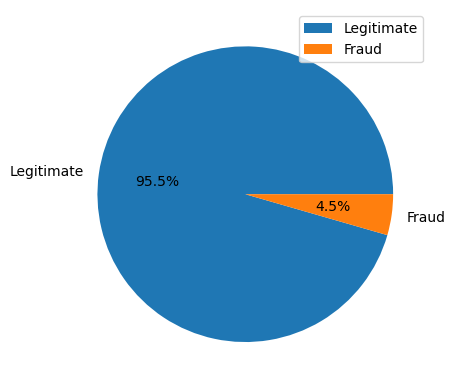

```python
import matplotlib.pyplot as plt
x=df["Is_Fraud"].value_counts()
x.index=["Legitimate" if i==0 else "Fraud" for i in x.index]
x.plot(kind="pie", autopct="%1.1f%%")
plt.ylabel("")
plt.legend()
plt.show()
```

2. Fraud Transaction Percentage

```python
df["Is_Fraud"].mean().round(4)*100
```

```
np.float64(4.46)
```

3. Average Transaction Amount

```python
df.groupby("Is_Fraud")["Transaction_Amount"].mean().round(2)
```

```
Is_Fraud
0.0    3109.04
1.0    3781.12
Name: Transaction_Amount, dtype: float64
```

4. Minimum and maximum transaction amount

```python
print("Minimum transaction amount:",df["Transaction_Amount"].min())
print("Maximum transaction amount:",df["Transaction_Amount"].max())
```

```
Minimum transaction amount: 21.84
Maximum transaction amount: 127257.73
```

5. Transaction Amount

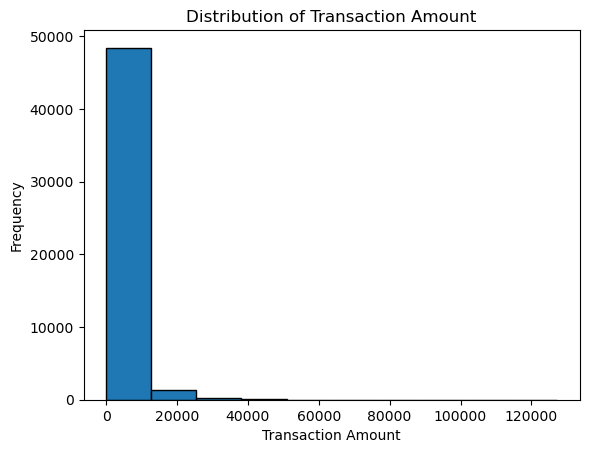

```python
df["Transaction_Amount"].plot(kind="hist",bins=10,edgecolor="black")
plt.xlabel("Transaction Amount")
plt.ylabel("Frequency")
plt.title("Distribution of Transaction Amount")
plt.show()
```

6. Transaction amount by Fraud Status

```python
df.groupby("Is_Fraud")["Transaction_Amount"].mean()
```

```
Is_Fraud
0.0    3109.036982
1.0    3781.118504
Name: Transaction_Amount, dtype: float64
```

visualization:

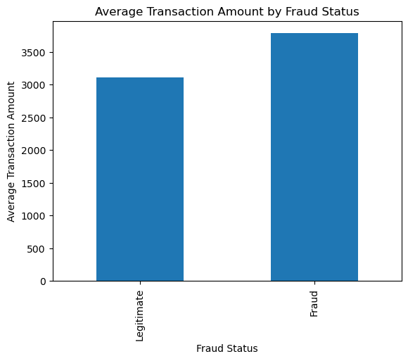

```python
x=df.groupby("Is_Fraud")["Transaction_Amount"].mean()
x.index=["Legitimate","Fraud"]
x.plot(kind="bar")
plt.xlabel("Fraud Status")
plt.ylabel("Average Transaction Amount")
plt.title("Average Transaction Amount by Fraud Status")
plt.show()
```

**Customer Details Analysis**

1. Gender distribution

```python
df["Customer_Gender"].value_counts()
```

[output not shown]

visualization:

[figure not shown]

```python
x=df["Customer_Gender"].value_counts()
x.plot(kind="pie",autopct="%1.1f%%")
plt.ylabel("")
plt.legend()
plt.show()
```

2. Card type distribution

```python
df["Card_Type"].value_counts()
```

```
Card_Type
Visa                21429
Mastercard          19077
RuPay                5583
American Express     3911
Name: count, dtype: int64
```

3. Card category distribution

```python
df["Card_Category"].value_counts()
```

```
Card_Category
Classic      20990
Gold         14994
Platinum      9988
Signature     4028
Name: count, dtype: int64
```

4. Device type distribution

```python
df["Device_Type"].value_counts()
```

```
Device_Type
Mobile          22341
Desktop         12524
POS Terminal    11131
Tablet           4004
Name: count, dtype: int64
```

**Fraud Analysis**

1. Average Customer Income vs Fraud Status

```python
df.groupby("Is_Fraud")["Customer_Income"].mean().round(2)
```

```
Is_Fraud
0.0    75663.81
1.0    75625.86
Name: Customer_Income, dtype: float64
```

2. Credit Score vs Fraud Status

```python
df.groupby("Is_Fraud")["Credit_Score"].mean().round(2)
```

```
Is_Fraud
0.0    719.77
1.0    720.97
Name: Credit_Score, dtype: float64
```

3. Transaction Channel vs Fraud Status

```python
pd.crosstab(df["Transaction_Channel"],df["Is_Fraud"])
```

| Is_Fraud Transaction_Channel | 0.0 | 1.0 |
| --- | --- | --- |
| ATM | 3769 | 174 |
| Contactless | 7192 | 343 |
| Mobile App | 4711 | 196 |
| Online | 17320 | 794 |
| POS | 14776 | 725 |

4. Payment Method vs Fraud Status

```python
pd.crosstab(df["Payment_Method"],df["Is_Fraud"])
```

| Is_Fraud Payment_Method | 0.0 | 1.0 |
| --- | --- | --- |
| Chip | 16255 | 777 |
| Contactless | 11847 | 539 |
| Mobile Wallet | 3839 | 170 |
| Online Card | 12093 | 572 |
| Swipe | 3734 | 174 |

Visualization:

[figure not shown]

```python
x=pd.crosstab(df["Transaction_Channel"],df["Is_Fraud"])
x.plot(kind="bar")
plt.xlabel("Transaction Channel")
plt.ylabel("Number of Transactions")
plt.title("Fraud Status by Transaction Channel")
plt.legend(title="Fraud Status")
plt.show()
```

5. Card Type vs Fraud Status

```python
pd.crosstab(df["Card_Type"],df["Is_Fraud"])
```

| Is_Fraud Card_Type | 0.0 | 1.0 |
| --- | --- | --- |
| American Express | 3727 | 184 |
| Mastercard | 18226 | 851 |
| RuPay | 5330 | 253 |
| Visa | 20485 | 944 |

6. Authentication Method vs Fraud Status

```python
pd.crosstab(df["Authentication_Method"],df["Is_Fraud"])
```

| Is_Fraud Authentication_Method | 0.0 | 1.0 |
| --- | --- | --- |
| 3D Secure | 10646 | 483 |
| Biometric | 6642 | 318 |
| OTP | 15296 | 708 |
| PIN | 11921 | 541 |

7. Device Type vs Fraud Status

```python
pd.crosstab(df["Device_Type"],df["Is_Fraud"])
```

| Is_Fraud Device_Type | 0.0 | 1.0 |
| --- | --- | --- |
| Desktop | 11989 | 535 |
| Mobile | 21348 | 993 |
| POS Terminal | 10610 | 521 |
| Tablet | 3821 | 183 |

8. Weekend vs Fraud Status

```python
pd.crosstab(df["Is_Weekend"],df["Is_Fraud"])
```

| Is_Fraud Is_Weekend | 0.0 | 1.0 |
| --- | --- | --- |
| No | 34106 | 1600 |
| Yes | 13662 | 632 |

9. Average Transaction Amount by Number of Transactions in Last 24 Hours

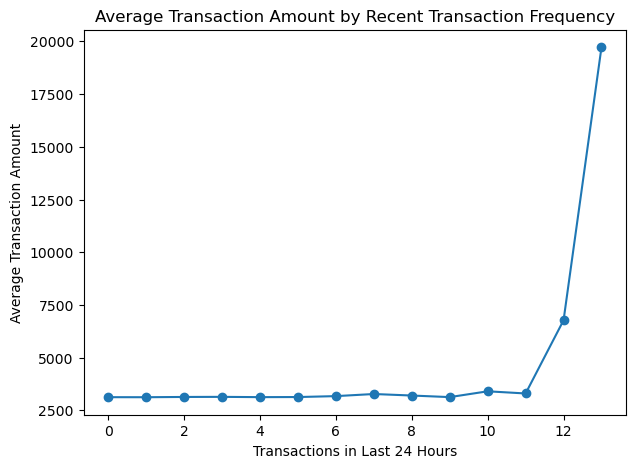

```python
avg_amount=df.groupby("Transactions_Last_24H")["Transaction_Amount"].mean().head(15)
avg_amount.plot(kind="line",marker="o",figsize=(7,5))
plt.xlabel("Transactions in Last 24 Hours")
plt.ylabel("Average Transaction Amount")
plt.title("Average Transaction Amount by Recent Transaction Frequency")
plt.show()
```

10. Fraud Rate by Transaction Hour

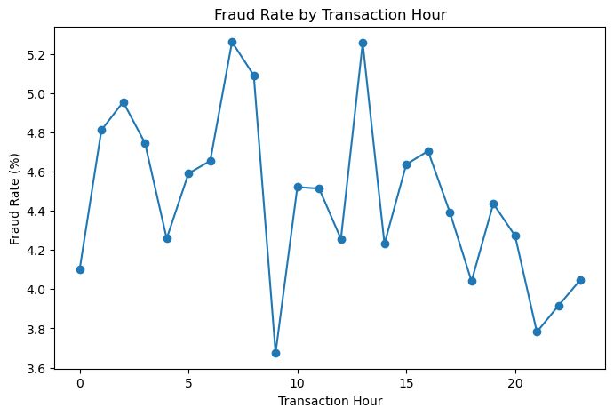

```python
fraud_by_hour=df.groupby("Transaction_Hour")["Is_Fraud"].mean()*100
fraud_by_hour.plot(kind="line",marker="o",figsize=(8,5))
plt.xlabel("Transaction Hour")
plt.ylabel("Fraud Rate (%)")
plt.title("Fraud Rate by Transaction Hour")
plt.show()
```

**Step-7: Data Preprocessing**

```python
df.columns
```

```
Index(['Card_Type', 'Card_Category', 'Customer_Age', 'Customer_Gender',
       'Customer_Income', 'Credit_Limit', 'Credit_Score', 'Account_Age_Months',
       'Card_Tenure_Months', 'Transaction_Amount', 'Currency',
       'Merchant_Category', 'Merchant_Country', 'Merchant_City',
       'Transaction_Channel', 'Payment_Method', 'Device_Type',
       'Operating_System', 'Browser', 'IP_Risk_Score', 'VPN_Used',
       'Proxy_Used', 'Transaction_Hour', 'Day_of_Week', 'Is_Weekend',
       'Previous_Transaction_Gap_Minutes', 'Transactions_Last_24H',
       'Transactions_Last_7D', 'Avg_Transaction_Amount_30D',
       'Amount_Deviation_Pct', 'Distance_From_Last_Transaction_KM',
       'CVV_Provided', 'PIN_Used', 'OTP_Used', 'Authentication_Method',
       'Failed_Authentication_Count', 'Card_Present', 'Is_Fraud',
       'Customer_Country', 'Customer_State', 'Customer_City', 'Year', 'Month',
       'Quarter', 'Month_Name', 'Amount_to_CreditLimit_Ratio',
       'Amount_to_Average_Ratio', 'High_Risk_Transaction', 'High_Frequency'],
      dtype='object')
```

```python
numeric_columns=df.select_dtypes(include=["int64","float64","int32","float32","bool"]).columns
for col in numeric_columns:
    if col != "Is_Fraud":
        df[col]=df[col].fillna(df[col].median())
```

```python
categorical_columns=df.select_dtypes(include=["object","category"]).columns
for col in categorical_columns:
    df[col]=df[col].fillna(df[col].mode()[0])
```

```python
binary_columns=["VPN_Used","Proxy_Used","Is_Weekend","CVV_Provided","PIN_Used","OTP_Used","Card_Present","High_Risk_Transaction","High_Frequency"]
for col in binary_columns:
    if col in df.columns:
        df[col]=df[col].map({"Yes":1,"No":0,True:1,False:0}).fillna(df[col])
```

```python
from sklearn.preprocessing import LabelEncoder
le=LabelEncoder()
for col in df.select_dtypes(include=["object","category"]).columns:
    df[col]=le.fit_transform(df[col].astype(str))
```

```python
from sklearn.preprocessing import StandardScaler
scaler=StandardScaler()
scale_columns=[c for c in ["Customer_Age","Customer_Income","Credit_Limit","Credit_Score","Account_Age_Months","Card_Tenure_Months","Transaction_Amount","IP_Risk_Score","Transaction_Hour","Previous_Transaction_Gap_Minutes","Transactions_Last_24H","Transactions_Last_7D","Avg_Transaction_Amount_30D","Amount_Deviation_Pct","Distance_From_Last_Transaction_KM","Failed_Authentication_Count","Year","Month","Quarter","Amount_to_CreditLimit_Ratio","Amount_to_Average_Ratio"] if c in df.columns]
df[scale_columns]=scaler.fit_transform(df[scale_columns])
```

```python
df.head()
```

|  | Card_Type | Card_Category | Customer_Age | Customer_Gender | Customer_Income | Credit_Limit | Credit_Score | Account_Age_Months | Card_Tenure_Months | Transaction_Amount | ... | Customer_State | Customer_City | Year | Month | Quarter | Month_Name | Amount_to_CreditLimit_Ratio | Amount_to_Average_Ratio | High_Risk_Transaction | High_Frequency |
| --- | --- | --- | --- | --- | --- | --- | --- | --- | --- | --- | --- | --- | --- | --- | --- | --- | --- | --- | --- | --- | --- |
| 0 | 2 | 0 | -0.216394 | 0 | -0.545192 | 2.438008 | -0.806229 | 1.663170 | 0.557999 | -0.101496 | ... | 8 | 4 | -1.629765 | -1.706869 | -1.354744 | 4 | -0.393075 | -0.364647 | 0 | 0 |
| 1 | 3 | 2 | 1.682049 | 0 | 0.409999 | -0.905707 | 0.193190 | -1.075272 | -0.736869 | -0.459092 | ... | 9 | 1 | -1.629765 | -1.706869 | -1.354744 | 4 | 0.012013 | -0.382137 | 0 | 0 |
| 2 | 3 | 0 | 0.176387 | 2 | -0.065174 | -0.905707 | 0.501834 | 1.513412 | 1.315970 | 1.264162 | ... | 8 | 11 | -1.629765 | -1.706869 | -1.354744 | 4 | 3.359313 | 0.681722 | 0 | 0 |
| 3 | 3 | 0 | -0.936493 | 1 | -1.038435 | -0.729722 | -0.747440 | 1.320865 | -1.052690 | -0.470702 | ... | 1 | 9 | -1.629765 | -1.706869 | -1.354744 | 4 | -0.230746 | -0.134528 | 0 | 0 |
| 4 | 0 | 1 | -1.329275 | 0 | 2.680817 | -0.025782 | 2.206725 | 1.256683 | 1.379134 | -0.309241 | ... | 0 | 9 | -1.629765 | -1.706869 | -1.354744 | 4 | -0.325280 | 0.277436 | 0 | 0 |

5 rows × 49 columns

**Step-8: Splitting the data**

Input Features:

```python
feature_columns=[c for c in df.columns if c!="Is_Fraud"]
X=df[feature_columns]
```

Target Variable:

```python
y=df["Is_Fraud"]
```

Splitting the data:

```python
from sklearn.model_selection import train_test_split

# Remove rows where target is missing
valid_rows = y.notna()

X = X.loc[valid_rows]
y = y.loc[valid_rows]

# Convert target to integer
y = y.astype(int)

# Split the data
X_train, X_test, y_train, y_test = train_test_split(
    X,
    y,
    test_size=0.2,
    random_state=42,
    stratify=y
)

print("X_train:", X_train.shape)
print("X_test:", X_test.shape)
print("y_train:", y_train.shape)
print("y_test:", y_test.shape)
```

```
X_train: (40000, 48)
X_test: (10000, 48)
y_train: (40000,)
y_test: (10000,)
```

Check the sizes:

```python
print(X_train.shape)
print(X_test.shape)
print(y_train.shape)
print(y_test.shape)
```

[output not shown]

**Step-9: Model Training**

```python
from sklearn.model_selection import train_test_split

# Remove rows where target is missing
valid_rows = y.notna()

X = X.loc[valid_rows]
y = y.loc[valid_rows]

# Convert target to integer
y = y.astype(int)

# Split data into training and testing sets
X_train, X_test, y_train, y_test = train_test_split(
    X,
    y,
    test_size=0.2,
    random_state=42,
    stratify=y
)

print("X_train:", X_train.shape)
print("X_test:", X_test.shape)
print("y_train:", y_train.shape)
print("y_test:", y_test.shape)
```

```
X_train: (40000, 48)
X_test: (10000, 48)
y_train: (40000,)
y_test: (10000,)
```

```python
from sklearn.model_selection import train_test_split

# Remove rows where target is missing
valid_rows = y.notna()

X = X.loc[valid_rows]
y = y.loc[valid_rows]

# Convert target to integer
y = y.astype(int)

# Split the data
X_train, X_test, y_train, y_test = train_test_split(
    X,
    y,
    test_size=0.2,
    random_state=42,
    stratify=y
)

print("X_train:", X_train.shape)
print("X_test:", X_test.shape)
print("y_train:", y_train.shape)
print("y_test:", y_test.shape)
```

```
X_train: (40000, 48)
X_test: (10000, 48)
y_train: (40000,)
y_test: (10000,)
```

```python
from sklearn.ensemble import RandomForestClassifier

model_rf = RandomForestClassifier(
    n_estimators=100,
    random_state=42,
    class_weight="balanced"
)

model_rf.fit(X_train, y_train)
```

```
RandomForestClassifier(class_weight='balanced', random_state=42)
```

```python
from sklearn.model_selection import train_test_split

# Remove rows where y is missing
mask = y.notna()

X = X.loc[mask]
y = y.loc[mask]

# Make target numeric
y = y.astype(int)

# Split
X_train, X_test, y_train, y_test = train_test_split(
    X,
    y,
    test_size=0.2,
    random_state=42,
    stratify=y
)

print("X_train:", X_train.shape)
print("X_test:", X_test.shape)
print("y_train:", y_train.shape)
print("y_test:", y_test.shape)
```

```
X_train: (40000, 48)
X_test: (10000, 48)
y_train: (40000,)
y_test: (10000,)
```

```python
from sklearn.linear_model import LogisticRegression

model = LogisticRegression(
    max_iter=2000,
    class_weight="balanced"
)

model.fit(X_train, y_train)

print("Logistic Regression model trained successfully.")
```

```
Logistic Regression model trained successfully.
```

```python
from sklearn.model_selection import train_test_split

# Remove missing target values
mask = y.notna()

X = X.loc[mask]
y = y.loc[mask]

# Convert target to integer
y = y.astype(int)

# Train-test split
X_train, X_test, y_train, y_test = train_test_split(
    X,
    y,
    test_size=0.2,
    random_state=42,
    stratify=y
)

print("X_train:", X_train.shape)
print("X_test:", X_test.shape)
print("y_train:", y_train.shape)
print("y_test:", y_test.shape)
```

```
X_train: (40000, 48)
X_test: (10000, 48)
y_train: (40000,)
y_test: (10000,)
```

```python
from sklearn.model_selection import train_test_split

# Check that X and y exist
print("X shape before split:", X.shape)
print("y shape before split:", y.shape)

# Remove missing target values
mask = y.notna()
X = X.loc[mask].copy()
y = y.loc[mask].copy()

# Convert target
y = y.astype(int)

# Create train and test data
X_train, X_test, y_train, y_test = train_test_split(
    X,
    y,
    test_size=0.2,
    random_state=42,
    stratify=y
)

print("X_train:", X_train.shape)
print("X_test:", X_test.shape)
print("y_train:", y_train.shape)
print("y_test:", y_test.shape)
```

```
X shape before split: (50000, 48)
y shape before split: (50000,)
X_train: (40000, 48)
X_test: (10000, 48)
y_train: (40000,)
y_test: (10000,)
```

```python
from sklearn.model_selection import train_test_split

# Remove rows where target is missing
mask = y.notna()
X = X.loc[mask].copy()
y = y.loc[mask].copy()

# Convert target to integer
y = y.astype(int)

# Split the data
X_train, X_test, y_train, y_test = train_test_split(
    X,
    y,
    test_size=0.2,
    random_state=42,
    stratify=y
)

print("X_train:", X_train.shape)
print("X_test:", X_test.shape)
print("y_train:", y_train.shape)
print("y_test:", y_test.shape)
```

```
X_train: (40000, 48)
X_test: (10000, 48)
y_train: (40000,)
y_test: (10000,)
```

```python
from sklearn.model_selection import train_test_split

# Remove rows where target is missing
mask = y.notna()

X_clean = X.loc[mask].copy()
y_clean = y.loc[mask].copy()

# Convert target to integer
y_clean = y_clean.astype(int)

# Split
X_train, X_test, y_train, y_test = train_test_split(
    X_clean,
    y_clean,
    test_size=0.2,
    random_state=42,
    stratify=y_clean
)

print("SUCCESS!")
print("X_train:", X_train.shape)
print("X_test :", X_test.shape)
print("y_train:", y_train.shape)
print("y_test :", y_test.shape)
```

```
SUCCESS!
X_train: (40000, 48)
X_test : (10000, 48)
y_train: (40000,)
y_test : (10000,)
```

```python
from sklearn.model_selection import train_test_split

# Check whether X and y exist
print("X exists:", X.shape)
print("y exists:", y.shape)

# Remove rows where target is missing
valid_rows = y.notna()

X_clean = X.loc[valid_rows].copy()
y_clean = y.loc[valid_rows].copy()

# Convert target to integer
y_clean = y_clean.astype(int)

# Split data
X_train, X_test, y_train, y_test = train_test_split(
    X_clean,
    y_clean,
    test_size=0.2,
    random_state=42,
    stratify=y_clean
)

print("\nSPLIT SUCCESSFUL")
print("X_train:", X_train.shape)
print("X_test :", X_test.shape)
print("y_train:", y_train.shape)
print("y_test :", y_test.shape)
```

```
X exists: (50000, 48)
y exists: (50000,)

SPLIT SUCCESSFUL
X_train: (40000, 48)
X_test : (10000, 48)
y_train: (40000,)
y_test : (10000,)
```

```python
from sklearn.model_selection import train_test_split

print("Checking X and y...")

print("X:", X.shape)
print("y:", y.shape)

# Remove missing target values
valid_rows = y.notna()

X_clean = X.loc[valid_rows].copy()
y_clean = y.loc[valid_rows].copy()

# Make sure target is integer
y_clean = y_clean.astype(int)

# Train-test split
X_train, X_test, y_train, y_test = train_test_split(
    X_clean,
    y_clean,
    test_size=0.2,
    random_state=42,
    stratify=y_clean
)

print("================================")
print("TRAIN-TEST SPLIT SUCCESSFUL")
print("X_train:", X_train.shape)
print("X_test :", X_test.shape)
print("y_train:", y_train.shape)
print("y_test :", y_test.shape)
```

```
Checking X and y...
X: (50000, 48)
y: (50000,)
================================
TRAIN-TEST SPLIT SUCCESSFUL
X_train: (40000, 48)
X_test : (10000, 48)
y_train: (40000,)
y_test : (10000,)
```

```python
import pickle
with open("credit_card_fraud_model.pkl","wb") as file:
    pickle.dump(model,file)
```

```python
df.columns
```

```
Index(['Card_Type', 'Card_Category', 'Customer_Age', 'Customer_Gender',
       'Customer_Income', 'Credit_Limit', 'Credit_Score', 'Account_Age_Months',
       'Card_Tenure_Months', 'Transaction_Amount', 'Currency',
       'Merchant_Category', 'Merchant_Country', 'Merchant_City',
       'Transaction_Channel', 'Payment_Method', 'Device_Type',
       'Operating_System', 'Browser', 'IP_Risk_Score', 'VPN_Used',
       'Proxy_Used', 'Transaction_Hour', 'Day_of_Week', 'Is_Weekend',
       'Previous_Transaction_Gap_Minutes', 'Transactions_Last_24H',
       'Transactions_Last_7D', 'Avg_Transaction_Amount_30D',
       'Amount_Deviation_Pct', 'Distance_From_Last_Transaction_KM',
       'CVV_Provided', 'PIN_Used', 'OTP_Used', 'Authentication_Method',
       'Failed_Authentication_Count', 'Card_Present', 'Is_Fraud',
       'Customer_Country', 'Customer_State', 'Customer_City', 'Year', 'Month',
       'Quarter', 'Month_Name', 'Amount_to_CreditLimit_Ratio',
       'Amount_to_Average_Ratio', 'High_Risk_Transaction', 'High_Frequency'],
      dtype='object')
```

```python
print("Does X exist?", "X" in globals())
print("Does y exist?", "y" in globals())
print("Does X_train exist?", "X_train" in globals())
print("Does X_test exist?", "X_test" in globals())
print("Does y_train exist?", "y_train" in globals())
print("Does y_test exist?", "y_test" in globals())
```

```
Does X exist? True
Does y exist? True
Does X_train exist? True
Does X_test exist? True
Does y_train exist? True
Does y_test exist? True
```